# Ievads ggplot2 grafiskajā sistēmā

## scale_continuous()

Ar argumentu `breaks=` var noteikt vērtības, pie kādām veikt skalas dalījumu.

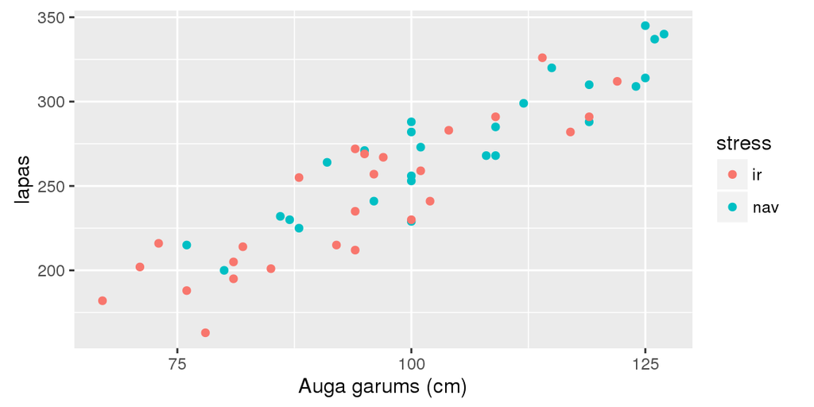

```r
ggplot(dati,aes(garums, lapas, color=stress)) + geom_point() +
      scale_x_continuous("Auga garums (cm)",breaks=c(75,100,125))
```

## scale_x_log10()

Ar funkcijām `scale_.._log10()`, `scale_.._sqrt()` var veikt automātisku skalu (asu) logaritmisko vai kvadrātsaknes transformāciju.

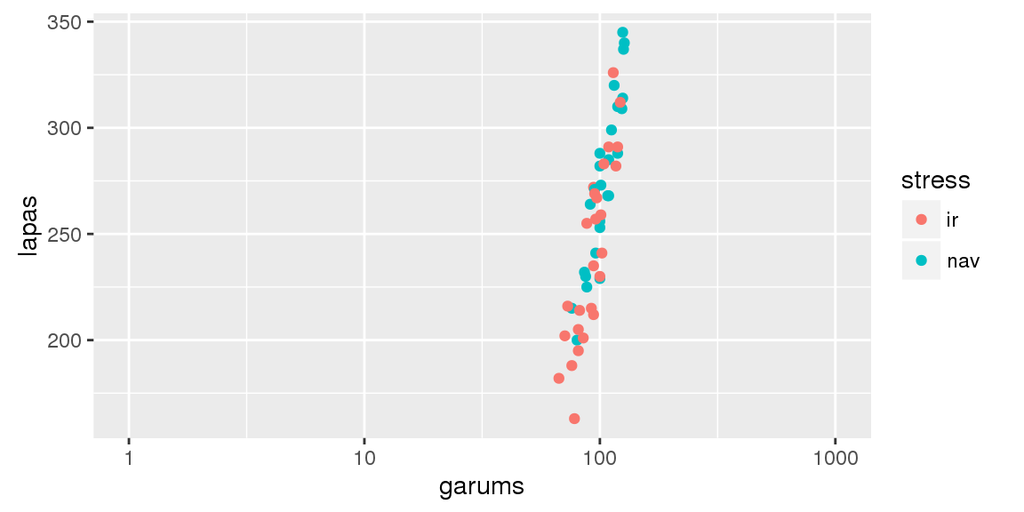

```r
ggplot(dati,aes(garums, lapas, color=stress)) + geom_point()  +
      scale_x_log10(limits=c(1,1000),breaks=c(1,10,100,1000))
```

## Nosaukumi

Nosaukumus asīm, attēlam leģendai var mainīt ne tikai ar skalu funkcijām, bet arī ar funkciju `labs()` un argumentiem, `x=`, `y=`, `title=`, `color=`, `fill=`, `size=`, …

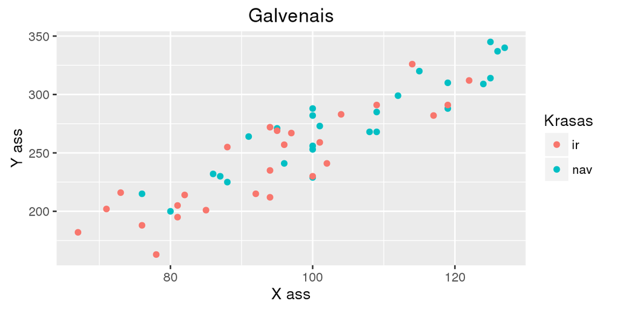

```r
ggplot(dati,aes(garums, lapas, color=stress)) + geom_point()  +
      labs(x = "X ass",y="Y ass",title="Galvenais",color="Krasas")
```

## Attēlu sadalīšana daļās

`ggplot2` sistēmā ir iespējams automātiski sadalīt attēlu vairākās daļās balstoties uz vienu vai vairākiem mainīgajiem. To panāk ar funkcijām `facet_grid()` un `facet_wrap()`.

Pirmajā gadījumā tiek izveidots rāmis, kur jānorāda mainīgais, kas dala x ass virzienā un y ass virzienā, bet `facet_wrap()` gadījumā dalījums notiek pēc viena mainīgā, norādot nepieciešamo rindu vai kolonnu skaitu.

## facet_grid()

```r
ggplot(dati,aes(garums, lapas)) + geom_point()
```

[output not shown]

## facet_grid()

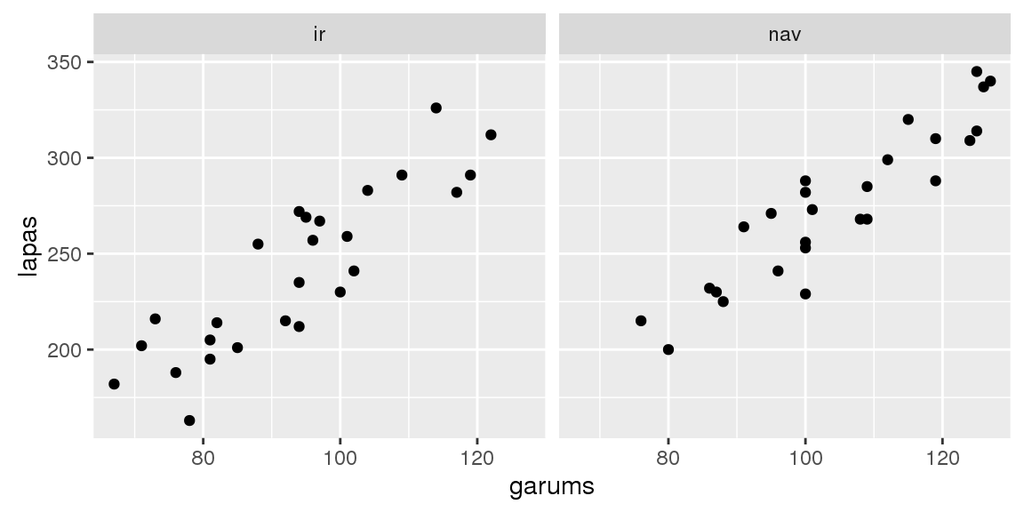

```r
ggplot(dati,aes(garums, lapas)) + geom_point()  + facet_grid(. ~ stress)
```

## facet_grid()

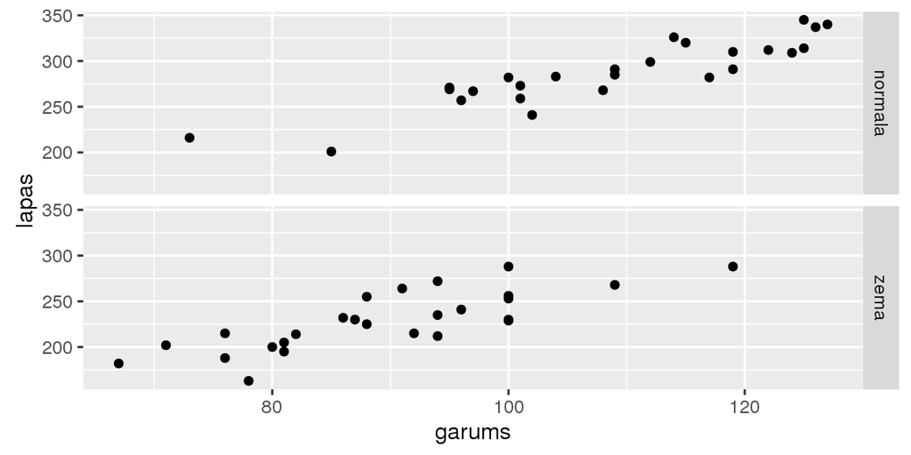

```r
ggplot(dati,aes(garums, lapas)) + geom_point() + facet_grid(gaisma ~ .)
```

## facet_grid()

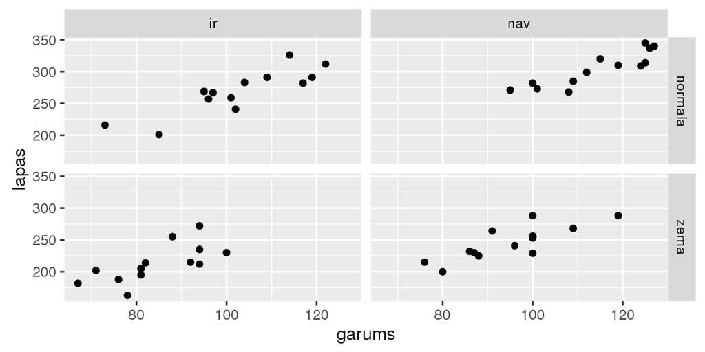

```r
ggplot(dati,aes(garums, lapas)) + geom_point() + facet_grid(gaisma ~ stress)
```

## facet_grid()

Ja funkcijai `facet_grid()` pieliek argumentu `margins=TRUE`, tad tiek izveidoti arī faktoru kombināciju attēli.

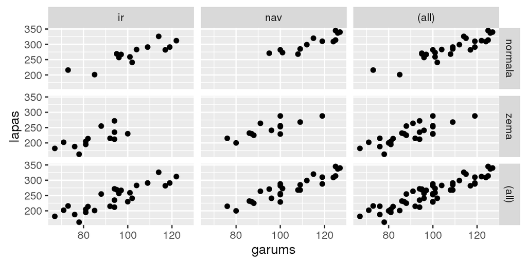

```r
ggplot(dati,aes(garums, lapas)) + geom_point() + facet_grid(gaisma ~ stress,margins = TRUE)
```

## facet_wrap()

```r
ggplot(dati,aes(garums, lapas)) + geom_point()
```

[output not shown]

## facet_wrap()

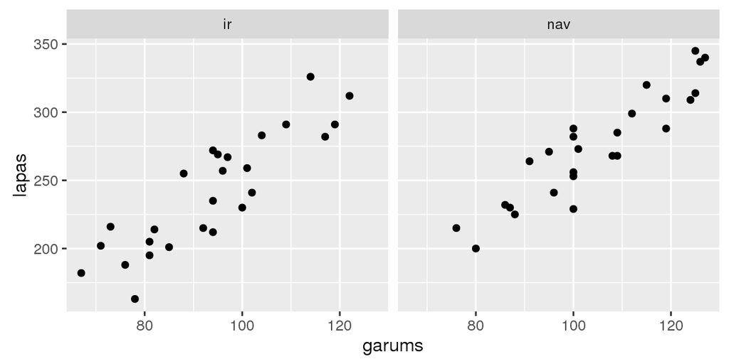

```r
ggplot(dati,aes(garums, lapas)) + geom_point() + facet_wrap(~ stress)
```

## facet_wrap()

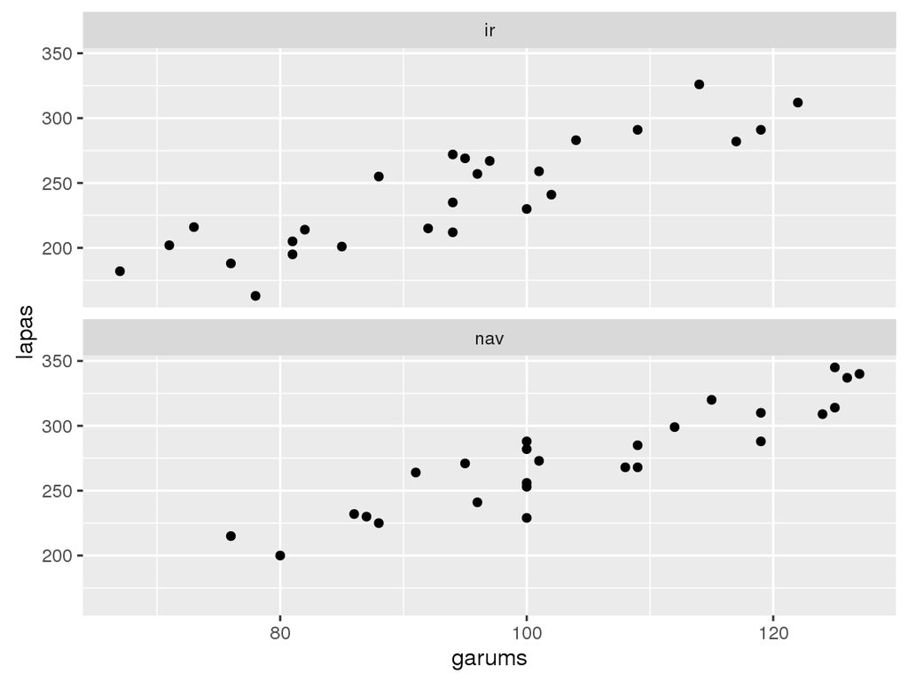

```r
ggplot(dati,aes(garums, lapas)) + geom_point() + facet_wrap(~ stress,ncol=1)
```

## Attēla izskata maiņa

Lai mainītu attēla izskatu, var izmantot gatavas tēmas vai arī mainīt katru elementu atsevišķi izmantojot funkciju `theme()`.

Gatavās tēmas, piemēram, ir `theme_bw()` vai `theme_minimal()`.

## theme_bw()

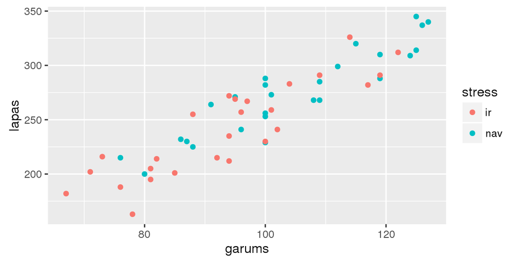

```r
ggplot(dati,aes(garums, lapas,color=stress)) + geom_point()
```

## theme_bw()

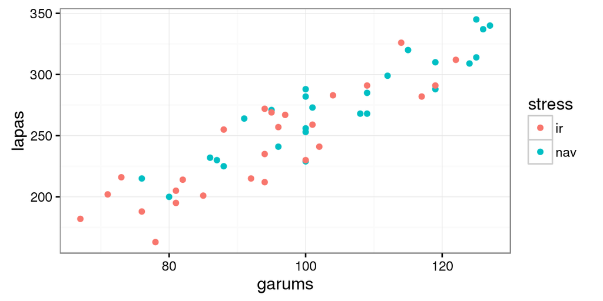

```r
ggplot(dati,aes(garums, lapas,color=stress)) + geom_point()+ theme_bw()
```

## theme_minimal()

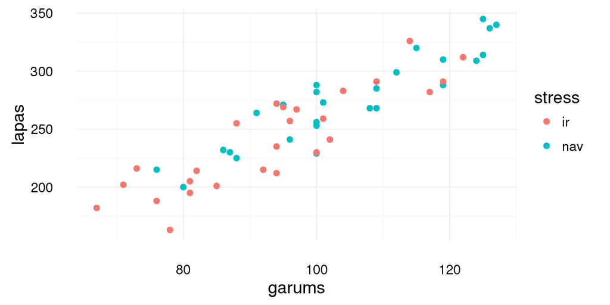

```r
ggplot(dati,aes(garums, lapas,color=stress)) + geom_point() +
      theme_minimal()
```

## theme_classic()

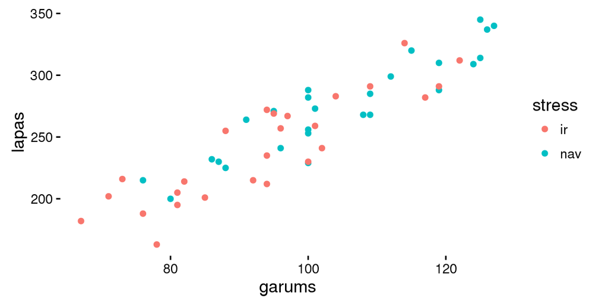

```r
ggplot(dati,aes(garums, lapas,color=stress)) + geom_point()+
      theme_classic()
```

## theme_excel()

Paketē `ggthemes` ir vairākas papildus noformējuma tēmas.

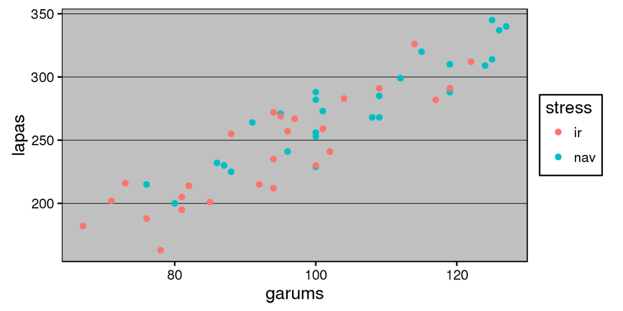

```r
if (!require("ggthemes") )  install.packages("ggthemes")
library(ggthemes)
ggplot(dati,aes(garums, lapas,color=stress)) + geom_point() +
      theme_excel()
```

## theme_wsj()

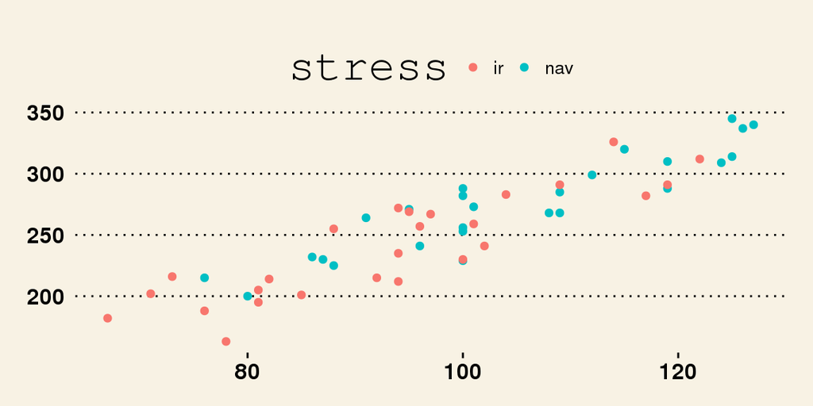

```r
ggplot(dati,aes(garums, lapas,color=stress)) + geom_point() +
      theme_wsj()
```

## theme_gdocs()

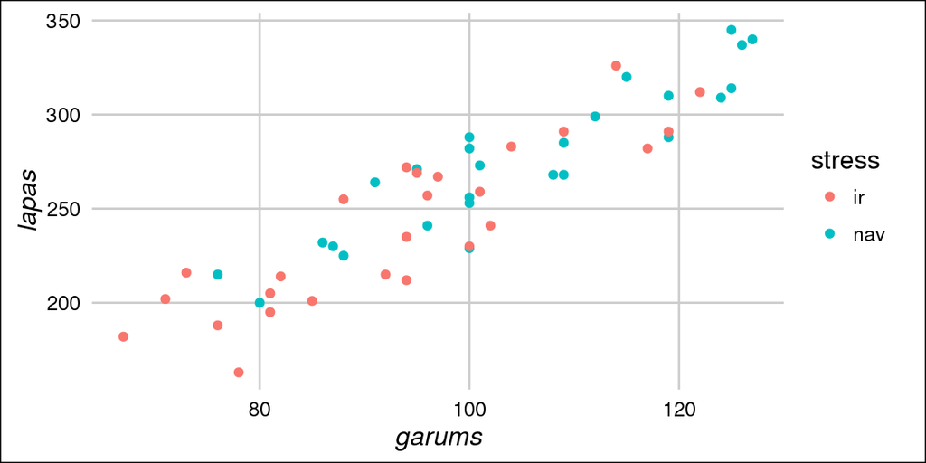

```r
ggplot(dati,aes(garums, lapas,color=stress)) + geom_point() +
      theme_gdocs()
```

## theme_tufte()

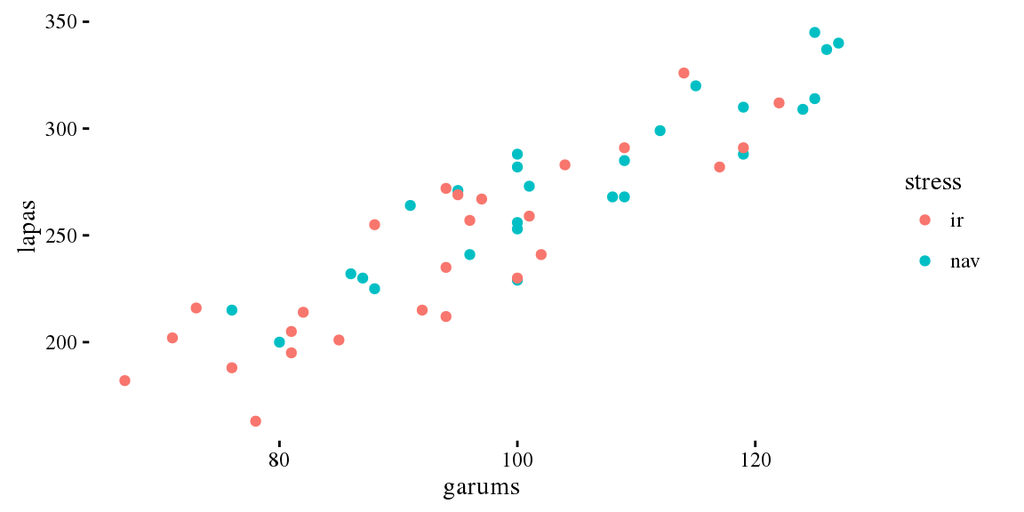

```r
ggplot(dati,aes(garums, lapas,color=stress)) + geom_point() +
      theme_tufte()
```

## theme()

Argumenti attēla elementu mainīšanai

- axis.title - asu paraksti (element_text)
- axis.title.x - x ass paraksts (element_text)
- axis.title.y - y ass paraksts (element_text)
- axis.text - apzīmējumi pie asīm (element_text)
- axis.text.x - apzīmējumi pie x ass (element_text)
- axis.text.y - apzīmējumi pie y ass (element_text)
- axis.ticks - nogriežņi pie asīm (element_line)
- axis.ticks.x - nogriežņi pie x ass (element_line)
- axis.ticks.y - nogriežņi pie y ass (element_line)
- axis.ticks.length - nogriežņu garums pie asīm (unit)
- axis.ticks.margin - atstarpe starp ass apzīmējumu un nogriežņiem (unit)
- axis.line - līnijas gar asīm (element_line)
- axis.line.x - līnijas pie x ass (element_line)
- axis.line.y - līnijas pie y ass (element_line)

## theme()

- legend.background - leģendas pamatne (element_rect)
- legend.margin - papildus atstarpe apkārt leģendai (unit)
- legend.key - pamatne zem leģendas ierakstiem (element_rect)
- legend.key.size - leģendas ierakstu izmērs (unit)
- legend.key.height - leģendas ieraksta pamatnes augstums (unit)
- legend.key.width - leģendas ieraksta pamatnes platums (unit)
- legend.text - leģendas ieraksti (element_text)
- legend.text.align - leģendas teksta novietojums (skaitlis no 0 līdz 1)
- legend.title - leģendas virsraksts (element_text)
- legend.title.align - leģendas virsraksta novietojums (skaitlis no 0 līdz 1)
- legend.position - leģendas novietojums ("left", "right", "bottom", "top", vai divu skaitļu vektors)
- legend.direction - leģendas ierakstu izvietojums ("horizontal" or "vertical")
- legend.justification - leģendas novietojums diagrammas iekšienē ("center" vai divu skaitļu vektors)
- legend.box - vairāku leģendu novietojums ("horizontal" or "vertical")
- panel.background - diagrammas iekšienes pametne (element_rect)
- panel.border - robeža apkārt diagrammas iekšienei (element_rect)

## theme()

- panel.margin - mala ap atsevišķām diagrammām (facet) (unit)
- panel.grid - grid lines (element_line)
- panel.grid.major - galvenās grid lines (element_line)
- panel.grid.minor - mazās grid lines (element_line)
- panel.grid.major.x - vertikālās galvenās grid lines (element_line)
- panel.grid.major.y - horizontālās galvenās grid lines (element_line)
- panel.grid.minor.x - vertikālās mazās grid lines (element_line)
- panel.grid.minor.y - horizontālās mazās grid lines (element_line)
- plot.background - visas diagrammas pamatne (element_rect)
- plot.title - diagrammas virsraksts (element_text)
- plot.margin - mala apkārt visai diagrammai (unit)
- strip.background - atsevišķu diagrammu (facet) uzrakstu pamatne (element_rect)
- strip.text - atsevišķu diagrammu (facet) uzraksts (element_text)
- strip.text.x - atsevišķu diagrammu (facet) uzraksts horizontālā virzienā (element_text)
- strip.text.y - atsevišķu diagrammu (facet) uzraksts vertikālā virzienā (element_text)

## theme()

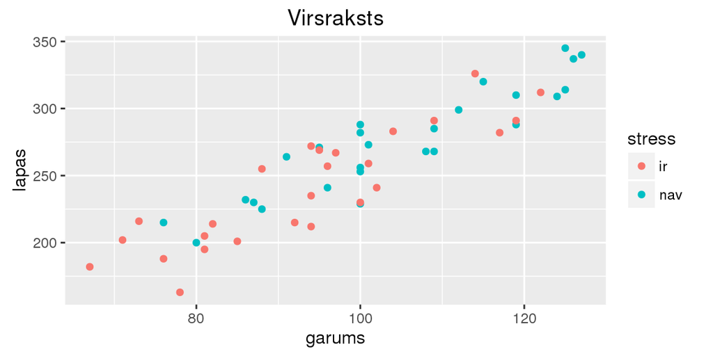

```r
ggplot(dati,aes(garums, lapas,color=stress)) + geom_point()+
      labs(title="Virsraksts")
```

## theme()

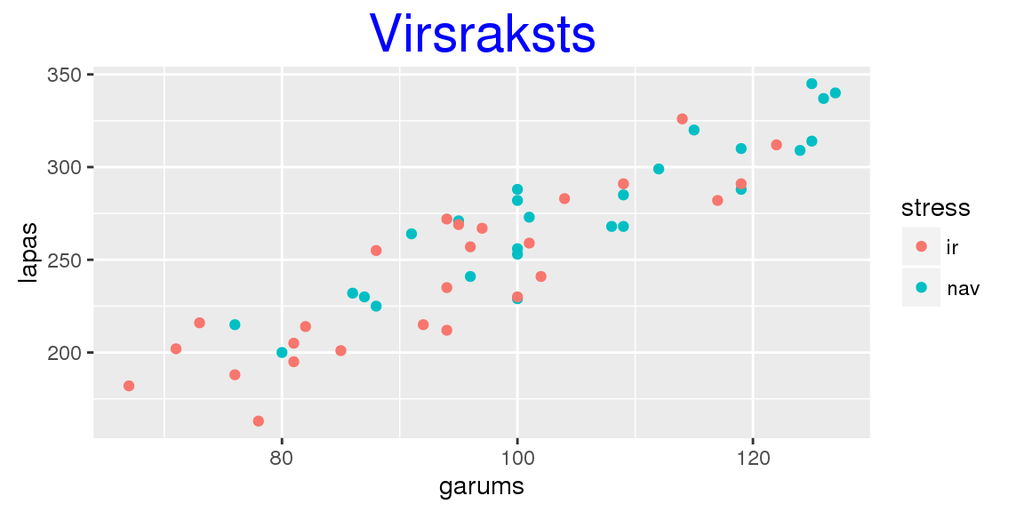

```r
ggplot(dati,aes(garums, lapas,color=stress)) + geom_point()+
      labs(title="Virsraksts") +
      theme(plot.title = element_text(size = rel(2),colour="blue"))
```

## theme()

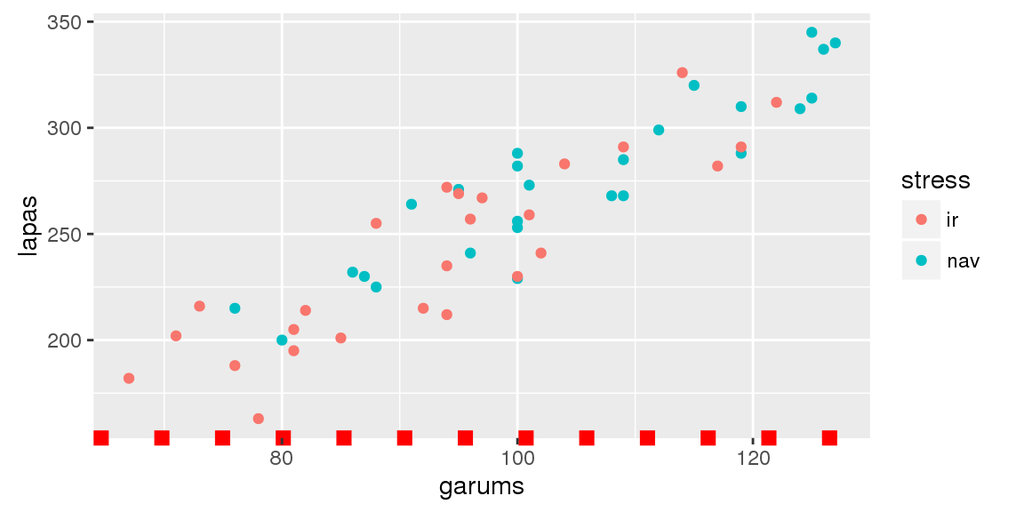

```r
ggplot(dati,aes(garums, lapas,color=stress)) + geom_point() +
      theme(axis.line.x = element_line(size = 3, colour = "red", linetype = "dotted"))
```

## theme()

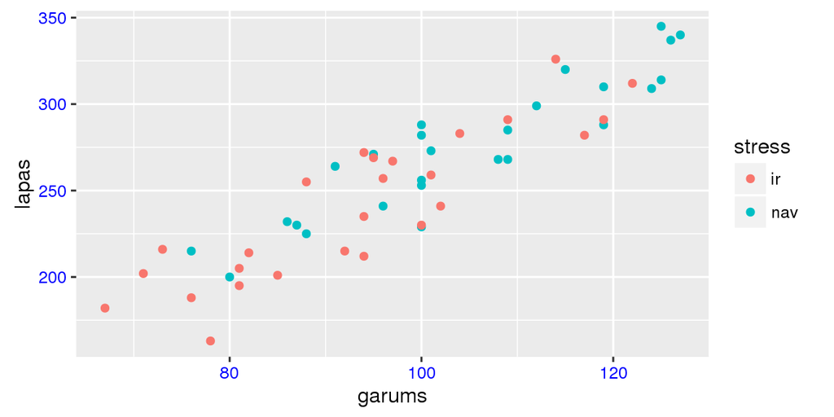

```r
ggplot(dati,aes(garums, lapas,color=stress)) + geom_point() +
      theme(axis.text = element_text(colour = "blue"))
```

## theme()

Jā kādu no elementiem nepieciešams pilnībā izslēgt/paslēpt, izmanto argumentu `element_blank()`.

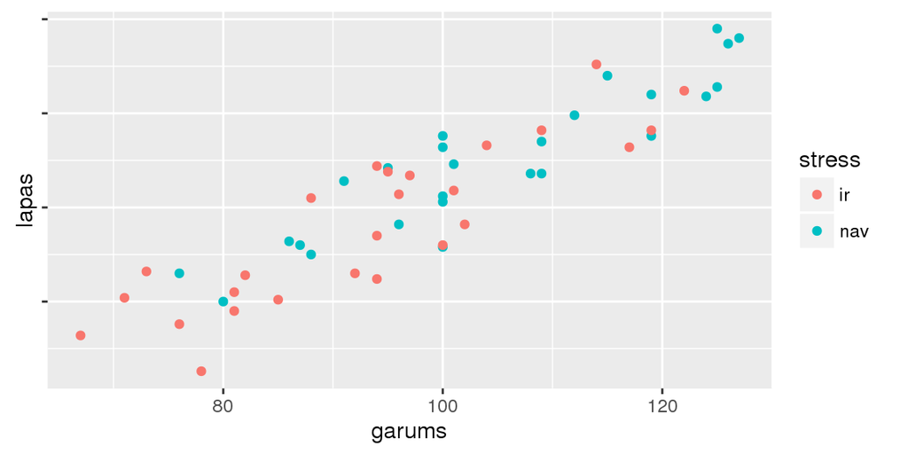

```r
ggplot(dati,aes(garums, lapas,color=stress)) + geom_point() +
      theme(axis.text.y = element_blank())
```

## theme()

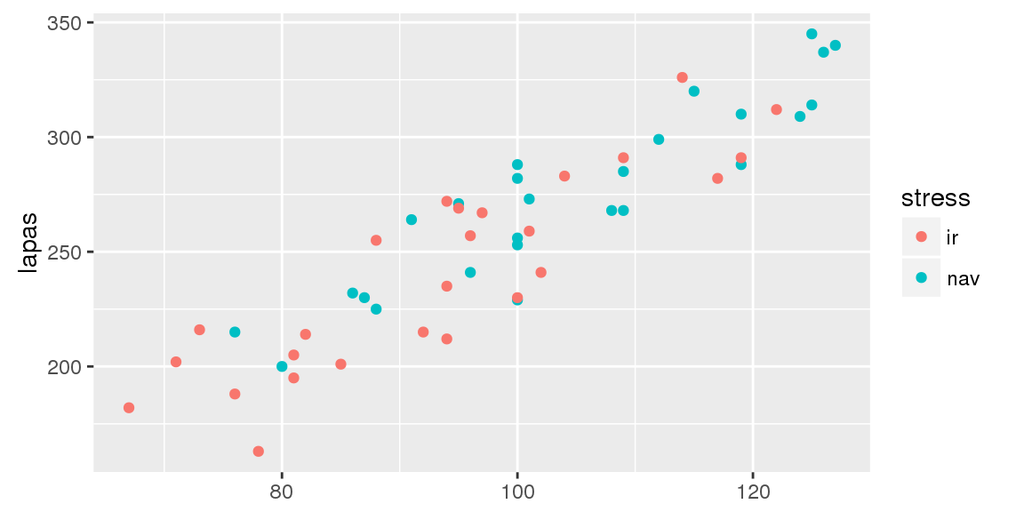

```r
ggplot(dati,aes(garums, lapas,color=stress)) + geom_point() +
      theme(axis.title.x = element_blank())
```

## theme()

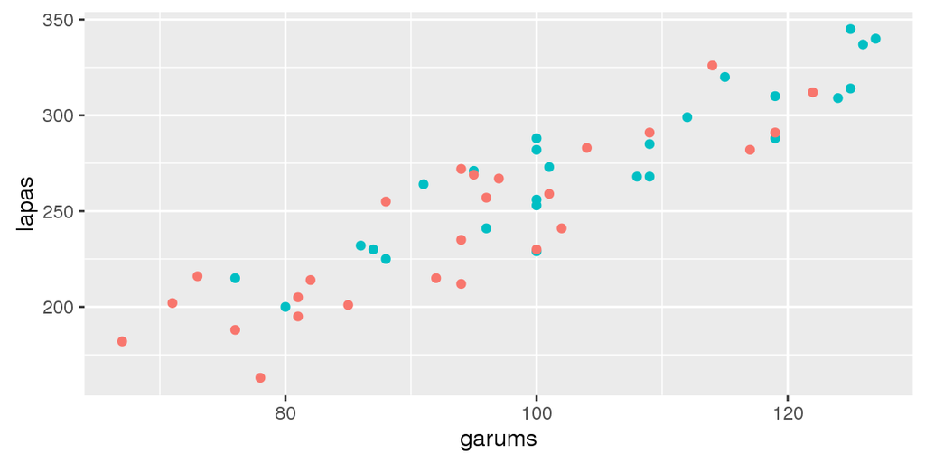

```r
ggplot(dati,aes(garums, lapas,color=stress)) + geom_point()+
      theme(legend.position = "none")
```

## theme()

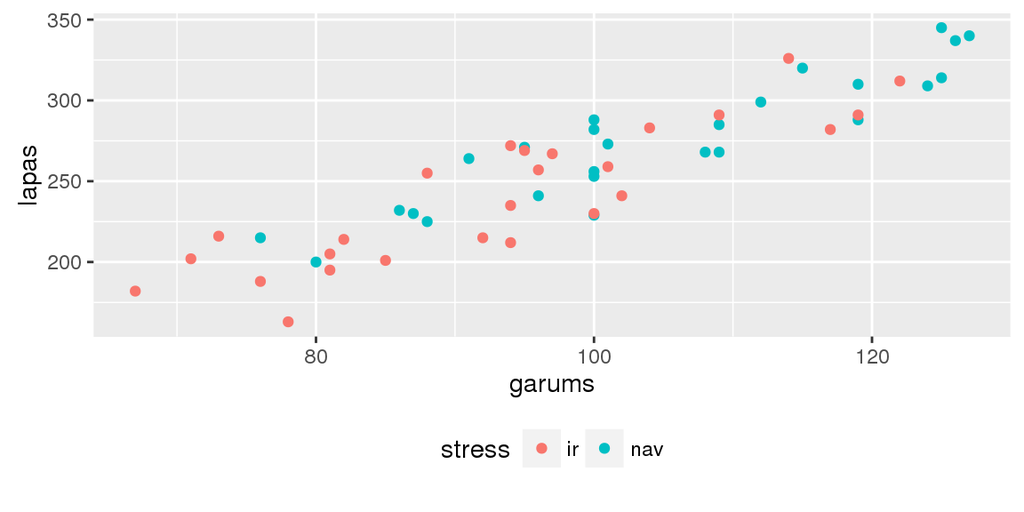

```r
ggplot(dati,aes(garums, lapas,color=stress)) + geom_point()+
      theme(legend.position = "bottom")
```

## theme()

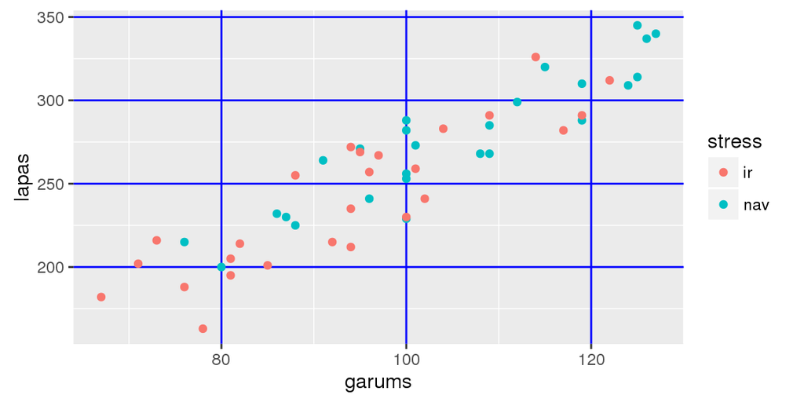

```r
ggplot(dati,aes(garums, lapas,color=stress)) + geom_point() +
      theme(panel.grid.major = element_line(colour = "blue"))
```

## theme()

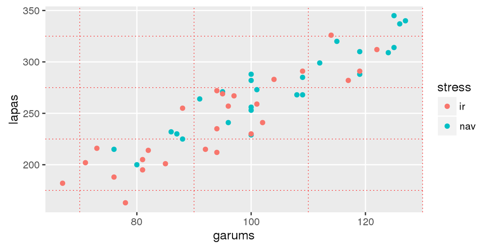

```r
ggplot(dati,aes(garums, lapas,color=stress)) + geom_point() +
      theme(panel.grid.minor = element_line(colour = "red", linetype = "dotted"))
```

## theme()

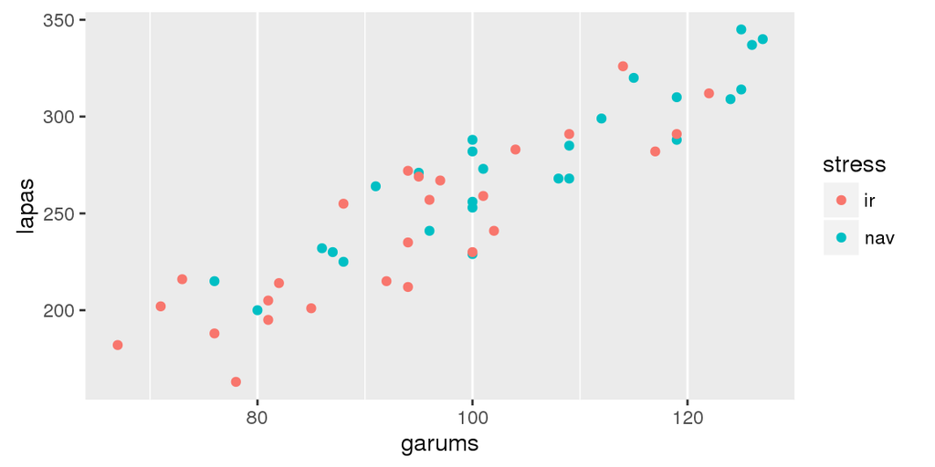

```r
ggplot(dati,aes(garums, lapas,color=stress)) + geom_point() +
      theme(panel.grid.major.y = element_blank(),
            panel.grid.minor.y = element_blank())
```

## theme()

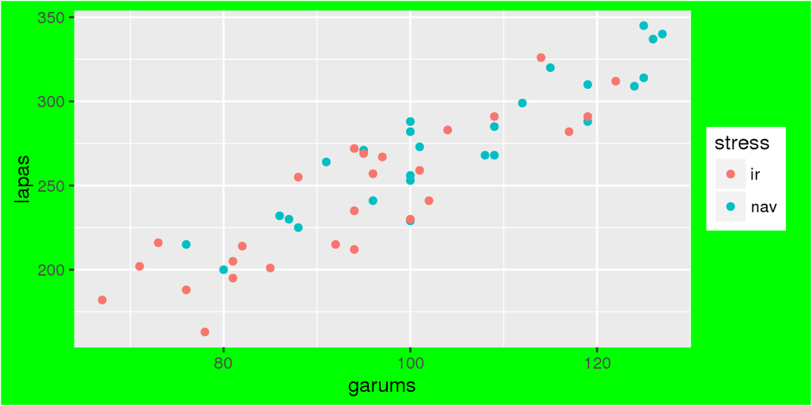

```r
ggplot(dati,aes(garums, lapas,color=stress)) + geom_point()+
      theme(plot.background = element_rect(fill = "green"))
```

## theme()

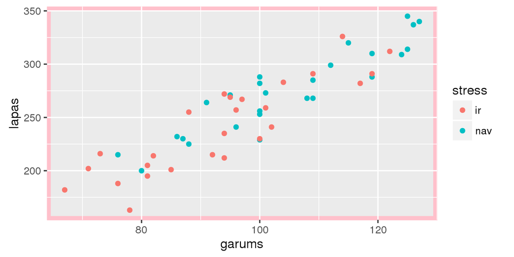

```r
ggplot(dati,aes(garums, lapas,color=stress)) + geom_point() +
      theme(panel.background = element_rect(colour = "pink",size=3))
```

## theme()

Katrs elements nav jānorāda savā `theme()` funkcijā, bet tos visus var iekļaut vienā funkcijā.

```r
ggplot(dati,aes(garums, lapas,color=stress)) + geom_point()+
  theme(axis.text.y=element_text(size=rel(1.2),face="bold"),
        axis.text.x=element_text(size=rel(1.2),face="bold",angle=90,vjust=0.5),
        axis.title=element_text(size=rel(1.5),face="bold"),
        axis.line.x=element_line(color="black"),
        panel.background=element_blank(),
        panel.grid.minor=element_blank(),
        panel.grid.major=element_line(color="grey90"),
        legend.position="top",
        legend.key=element_rect(fill="white"),
        legend.title=element_text(size=rel(1.5)),
        legend.text=element_text(size=rel(1.5)))
```

## theme()

[figure not shown]

## Attēlu saglabāšana

ggplot2 attēlus var saglabāt arī pēc to izveidošanas.

Lai saglabātu attēlu, izmanto funkciju `ggsave()`, kurā jānorāda vēlamais faila nosaukums ar paplašinājumu, izmērs (pēc noklusējuma collās). Šo komandu izpilda kā pēdējo.

`ggsave("1_attels.png",width=8,height=5)`

## Attēla veidošana no objektiem

Gan pašu attēlu, gan arī noformējuma nosacījumus var saglabāt kā atsevišķus argumentus un izmantot atkārtoti.

```r
p<-ggplot(dati,aes(garums, lapas,color=stress)) + geom_point()

noformejums<-  theme(axis.text.y=element_text(size=rel(1.2),face="bold"),
        axis.text.x=element_text(size=rel(1.2),face="bold",angle=90,vjust=0.5),
        axis.title=element_text(size=rel(1.5),face="bold"),
        axis.line.x=element_line(color="black"),
        panel.background=element_blank(),
        panel.grid.minor=element_blank(),
        panel.grid.major=element_line(color="grey90"),
        legend.position="top",
        legend.key=element_rect(fill="white"),
        legend.title=element_text(size=rel(1.5)),
        legend.text=element_text(size=rel(1.5)))
```

## Attēla veidošana no objektiem

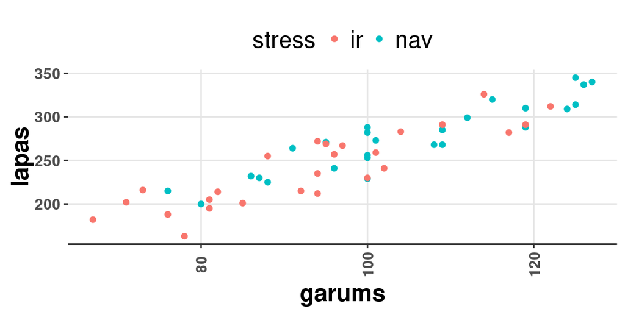

```r
p+noformejums
```

## Attēla veidošana no objektiem

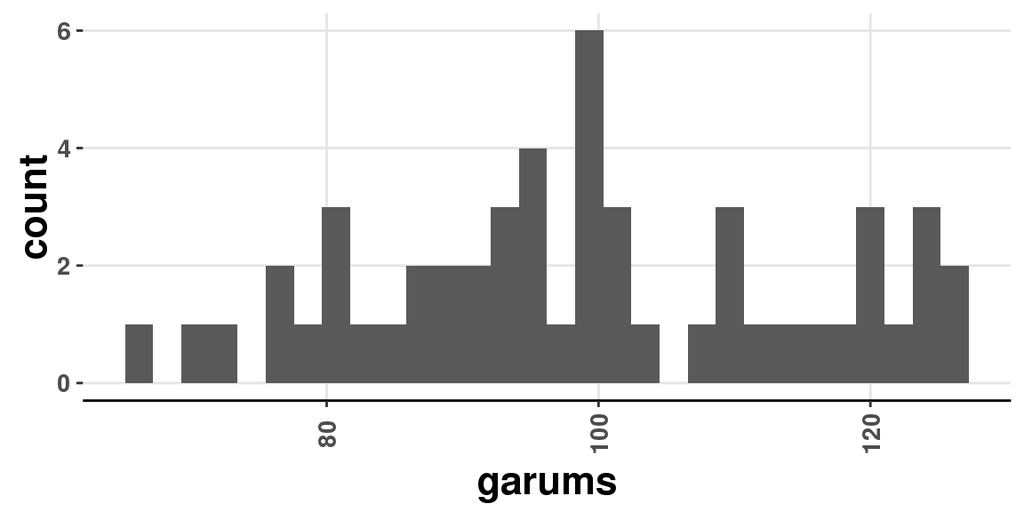

```r
ggplot(dati,aes(garums))+geom_histogram()+noformejums
```